# U.S. Automotive Industry -

# Exploratory Data Analysis (EDA) Report

Author: David Saucedo Date: Sept 19, 2022

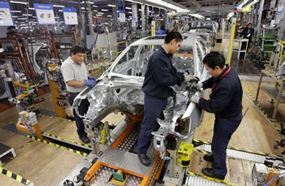

image info

### Loading Required Libraries

```r
library(foreign)
library(dplyr)        # data manipulation
library(forcats)      # to work with categorical variables
library(ggplot2)      # data visualization
library(janitor)      # data exploration and cleaning
library(Hmisc)        # several useful functions for data analysis
library(psych)        # functions for multivariate analysis
library(naniar)       # summaries and visualization of missing values NAs
library(dlookr)       # summaries and visualization of missing values NAs
library(corrplot)     # correlation plots
library(jtools)       # presentation of regression analysis
library(lmtest)       # diagnostic checks - linear regression analysis
library(car)          # diagnostic checks - linear regression analysis
library(olsrr)        # diagnostic checks - linear regression analysis
library(kableExtra)   # HTML table attributes
```

### Setting Working Directory

```r
setwd("D:\\Tec21\\CD2001C\\auto_data\\eda")
```

### Importing Datasets

```r
exports_data<-read.csv("exports.csv")
imports_data<-read.csv("imports.csv")
domestic_production_sales<-read.csv("us_motor_production_and_domestic_sales.csv")
us_consumer_confidence<-read.csv("us_consumer_confidence.csv")
```

## Exports of Automotive Parts - Data Description

- **APEC**: Asia-Pacific Economic Cooperation
- **ASEAN**: Association of Southeast Asian Nations
- **CAFTA**: The Dominican Republic - Central America - US Free Trade Agreement
- **EU without UK**: European Union without UK
- **EU**: European Union
- **FTA**: Free Trade Agreements
- **GCC**: Gulf Cooperation Council
- **MERCOSUR**: Latin American Southern Common Market
- **USMCA**: United States - Mexico - Canada Agreement
- **WORLD**: World Countries

## Imports of Automotive Parts - Data Description

- **Imports by Country**

## US Consumer Confidence

- **US_Unemployment**: Unemployment rate represents the number of unemployed as a percentage of the labor force.
- **US_Consumer_Confidence**: Reflects consumer attitudes, buying intentions, vaction plans, and consumer expectations for inflation, stock prices, and interest rates.
- **US_Min_Hour_Wage**: US Minimum Wage per Hour

## Domestic Production & Sales

- **Total_Production**: Annual U.S. Motor Vehicle Production (Thousands of Units)
- **Production_Passenger_Cars**: A passenger car is a road motor vehicle, other than a motor cycle, intended for the carriage of passengers and designed to seat no more than nine persons (including the driver)
- **Production_Commercial_Vehicles**: Includes trucks under 10,000 pounds including compact and conventional pickups, sport utility vehicles, minivans and vans.
- **Domestic_Sales**: Includes U.S. sales of cars produced in U.S., Canada, and Mexico.
- **Sales_Passenger_Cars**: Includes U.S. sales of cars produced in U.S., Canada, and Mexico.
- **Sales_Commercial_Vehicles**: Includes U.S. sales of cars produced in U.S., Canada, and Mexico. Also, it includes trucks under 10,000 pounds including compact and conventional pickups, sport utility vehicles, minivans and vans.

## Exploratory Data Analysis

**Exploratory Data Analysis (EDA)** is about visualizing, transforming, and modelling your data. This report analyzes the U.S. automotive industry with the aim to explore patterns, trends, and factors that might explain its performance over a period of time. Briefly,EDA is a combination of data analysis tools including: a. statistical methods such as summary of descriptive statistics b. data visualization c. data analysis to address exploratory questions

## Identify data structure (i.e., quantitative and qualitiative variables)

### str() display the internal structure of an object

```r
str(exports_data)
```

```
## 'data.frame':    14 obs. of  11 variables:
##  $ Year         : int  2008 2009 2010 2011 2012 2013 2014 2015 2016 2017 ...
##  $ APEC         : num  4.76e+10 3.58e+10 4.93e+10 5.75e+10 6.47e+10 ...
##  $ ASEAN        : int  634349796 496910667 680658257 840142324 1021425505 1025509891 881196178 840278661 1104744479 1278418305 ...
##  $ CAFTA        : int  367743212 278169351 323366663 351111333 397841948 335656182 355805887 435857956 471404121 464614512 ...
##  $ EU.Without.UK: num  4.62e+09 3.03e+09 3.86e+09 4.29e+09 4.06e+09 ...
##  $ EU28         : num  5.66e+09 3.65e+09 4.80e+09 5.43e+09 5.14e+09 ...
##  $ FTA.COUNTRIES: num  4.51e+10 3.40e+10 4.67e+10 5.43e+10 6.13e+10 ...
##  $ GCC          : int  692554806 650329536 726496013 821805242 906679772 1008453546 1187692693 1175890698 1036072844 1008430809 ...
##  $ MERCOSUR     : num  2.00e+09 1.43e+09 1.80e+09 2.10e+09 2.14e+09 ...
##  $ USMCA        : num  4.22e+10 3.18e+10 4.35e+10 5.01e+10 5.64e+10 ...
##  $ WORLD        : num  5.80e+10 4.32e+10 5.88e+10 6.84e+10 7.56e+10 ...
```

```r
str(imports_data)
```

```
## 'data.frame':    10 obs. of  22 variables:
##  $ Year          : int  2011 2012 2013 2014 2015 2016 2017 2018 2019 2020
##  $ WORLD         : num  1.14e+11 1.30e+11 1.32e+11 1.45e+11 1.50e+11 ...
##  $ Mexico        : num  3.56e+10 4.10e+10 4.43e+10 4.94e+10 5.31e+10 ...
##  $ Canada        : num  1.64e+10 1.74e+10 1.69e+10 1.82e+10 1.77e+10 ...
##  $ Japan         : num  1.50e+10 1.83e+10 1.59e+10 1.59e+10 1.49e+10 ...
##  $ China         : num  1.25e+10 1.50e+10 1.63e+10 1.85e+10 1.88e+10 ...
##  $ Germany       : num  8.18e+09 9.68e+09 9.82e+09 1.07e+10 1.13e+10 ...
##  $ Korea         : num  6.65e+09 7.96e+09 8.15e+09 8.72e+09 9.10e+09 ...
##  $ Thailand      : num  2.14e+09 2.05e+09 1.85e+09 2.07e+09 2.55e+09 ...
##  $ Taiwan        : num  2.40e+09 2.58e+09 2.69e+09 2.90e+09 3.12e+09 ...
##  $ Vietnam       : int  345732236 538203055 584549113 629615627 767493733 918085468 1190846356 1402210036 1615198359 1677877332
##  $ Italy         : int  932200896 1072907312 1124970737 1605517288 1635982971 1341877958 1116845799 1652848752 1437532018 1496377260
##  $ India         : int  1071073918 1172207458 1013037825 1279809263 1405909754 1266276897 1463297268 1794032694 1972813334 1492732169
##  $ United.Kingdom: int  941051070 1157500311 1296987508 1401974598 1325122574 1183398177 1306260209 1426837096 1402163242 1064167484
##  $ Austria       : int  1620785098 986227979 953013723 1377170974 1374426970 1123856030 1149686564 1044795780 1039913441 1046145774
##  $ Spain         : int  458459462 806208396 903254998 1040352939 1099663442 887199170 951972637 895766492 1036866601 968317134
##  $ Indonesia     : int  862168793 837466943 852472242 843263223 1067776023 1208877805 1139649360 1017771075 1012604055 933120548
##  $ Brazil        : int  1573108616 1511483389 1147106045 1095222918 1079459310 984115086 1129549832 1242780330 1253501298 932723467
##  $ Czech.Republic: int  537016014 646830143 675962109 742195021 871465387 830030843 832859063 832235411 863811133 779827827
##  $ Philippines   : int  487396820 563510760 632399731 769631373 916947819 852561649 854167135 859812827 1034365296 752421590
##  $ Malaysia      : int  220198346 286532785 273344913 319271461 383248338 393686684 373685441 501710178 627598424 679050429
##  $ Poland        : int  294213839 441431112 445754240 502824775 480998156 464644630 473389577 498810863 628584702 608946237
```

```r
str(domestic_production_sales)
```

```
## 'data.frame':    36 obs. of  7 variables:
##  $ Year                          : int  1965 1970 1975 1980 1985 1990 1991 1992 1993 1994 ...
##  $ Total_Production              : num  11114 8263 8965 8011 11638 ...
##  $ Production_Passenger_Cars     : num  9329 6546 6706 6372 8186 ...
##  $ Production_Commercial_Vehicles: num  1785 1717 2260 1638 3452 ...
##  $ Domestic_Sales                : num  10302 8849 9298 8594 12110 ...
##  $ Sales_Passenger_Cars          : num  8763 7112 6945 6580 8205 ...
##  $ Sales_Commercial_Vehicles     : num  1539 1737 2353 2015 3905 ...
```

```r
str(us_consumer_confidence)
```

```
## 'data.frame':    15 obs. of  4 variables:
##  $ Year                  : int  2007 2008 2009 2010 2011 2012 2013 2014 2015 2016 ...
##  $ US_Unemployment       : num  4.62 5.8 9.28 9.61 8.93 ...
##  $ US_Consumer_Confidence: num  85.6 63.8 66.3 71.8 67.3 ...
##  $ US_Min_Hour_Wage      : num  5.5 6.2 6.9 7.25 7.25 7.25 7.25 7.25 7.25 7.25 ...
```

## Variable Types

| Variable | Type |
| --- | --- |
| `Year` | quantiative (discrete) |
| `APEC` | quantiative (continous) |
| `ASEAN` | quantitative (continous) |
| `USMCA` | quantitative (continous) |

### Descriptive Statistics (e.g., mean, median, min, max)

### Exports Data

```r
summary(exports_data)
```

```
##       Year           APEC               ASEAN               CAFTA
##  Min.   :2008   Min.   :3.577e+10   Min.   :4.969e+08   Min.   :278169351
##  1st Qu.:2011   1st Qu.:5.587e+10   1st Qu.:8.402e+08   1st Qu.:352131115
##  Median :2014   Median :6.611e+10   Median :1.023e+09   Median :382792580
##  Mean   :2014   Mean   :6.144e+10   Mean   :1.015e+09   Mean   :398381579
##  3rd Qu.:2018   3rd Qu.:6.955e+10   3rd Qu.:1.232e+09   3rd Qu.:459128093
##  Max.   :2021   Max.   :7.344e+10   Max.   :1.502e+09   Max.   :520314206
##  EU.Without.UK            EU28           FTA.COUNTRIES
##  Min.   :3.032e+09   Min.   :3.645e+09   Min.   :3.403e+10
##  1st Qu.:4.321e+09   1st Qu.:5.390e+09   1st Qu.:5.040e+10
##  Median :5.084e+09   Median :6.282e+09   Median :6.218e+10
##  Mean   :5.072e+09   Mean   :6.330e+09   Mean   :5.700e+10
##  3rd Qu.:5.807e+09   3rd Qu.:7.360e+09   3rd Qu.:6.459e+10
##  Max.   :6.903e+09   Max.   :8.900e+09   Max.   :6.709e+10
##       GCC               MERCOSUR             USMCA
##  Min.   :6.503e+08   Min.   :1.122e+09   Min.   :3.177e+10
##  1st Qu.:8.310e+08   1st Qu.:1.469e+09   1st Qu.:4.707e+10
##  Median :9.483e+08   Median :1.645e+09   Median :5.753e+10
##  Mean   :9.264e+08   Mean   :1.730e+09   Mean   :5.320e+10
##  3rd Qu.:1.008e+09   3rd Qu.:1.967e+09   3rd Qu.:6.014e+10
##  Max.   :1.188e+09   Max.   :2.555e+09   Max.   :6.305e+10
##      WORLD
##  Min.   :4.324e+10
##  1st Qu.:6.725e+10
##  Median :7.695e+10
##  Mean   :7.329e+10
##  3rd Qu.:8.196e+10
##  Max.   :8.876e+10
```

### Imports Data

```r
summary(imports_data)
```

```
##       Year          WORLD               Mexico              Canada
##  Min.   :2011   Min.   :1.140e+11   Min.   :3.561e+10   Min.   :1.407e+10
##  1st Qu.:2013   1st Qu.:1.317e+11   1st Qu.:4.557e+10   1st Qu.:1.649e+10
##  Median :2016   Median :1.465e+11   Median :5.236e+10   Median :1.699e+10
##  Mean   :2016   Mean   :1.412e+11   Mean   :5.047e+10   Mean   :1.680e+10
##  3rd Qu.:2018   3rd Qu.:1.496e+11   3rd Qu.:5.501e+10   3rd Qu.:1.738e+10
##  Max.   :2020   Max.   :1.578e+11   Max.   :6.078e+10   Max.   :1.825e+10
##      Japan               China              Germany
##  Min.   :1.206e+10   Min.   :1.144e+10   Min.   :8.180e+09
##  1st Qu.:1.491e+10   1st Qu.:1.512e+10   1st Qu.:9.317e+09
##  Median :1.549e+10   Median :1.683e+10   Median :9.748e+09
##  Mean   :1.544e+10   Mean   :1.631e+10   Mean   :9.683e+09
##  3rd Qu.:1.604e+10   3rd Qu.:1.830e+10   3rd Qu.:9.995e+09
##  Max.   :1.831e+10   Max.   :2.012e+10   Max.   :1.128e+10
##      Korea              Thailand             Taiwan
##  Min.   :6.651e+09   Min.   :1.853e+09   Min.   :2.402e+09
##  1st Qu.:8.154e+09   1st Qu.:2.090e+09   1st Qu.:2.745e+09
##  Median :8.497e+09   Median :2.770e+09   Median :3.039e+09
##  Mean   :8.453e+09   Mean   :2.881e+09   Mean   :2.971e+09
##  3rd Qu.:9.040e+09   3rd Qu.:3.421e+09   3rd Qu.:3.214e+09
##  Max.   :9.411e+09   Max.   :4.327e+09   Max.   :3.407e+09
##     Vietnam              Italy               India
##  Min.   :3.457e+08   Min.   :9.322e+08   Min.   :1.013e+09
##  1st Qu.:5.958e+08   1st Qu.:1.119e+09   1st Qu.:1.196e+09
##  Median :8.428e+08   Median :1.390e+09   Median :1.343e+09
##  Mean   :9.670e+08   Mean   :1.342e+09   Mean   :1.393e+09
##  3rd Qu.:1.349e+09   3rd Qu.:1.578e+09   3rd Qu.:1.485e+09
##  Max.   :1.678e+09   Max.   :1.653e+09   Max.   :1.973e+09
##  United.Kingdom         Austria              Spain
##  Min.   :9.411e+08   Min.   :9.530e+08   Min.   :4.585e+08
##  1st Qu.:1.164e+09   1st Qu.:1.041e+09   1st Qu.:8.893e+08
##  Median :1.302e+09   Median :1.085e+09   Median :9.276e+08
##  Mean   :1.251e+09   Mean   :1.172e+09   Mean   :9.048e+08
##  3rd Qu.:1.383e+09   3rd Qu.:1.318e+09   3rd Qu.:1.020e+09
##  Max.   :1.427e+09   Max.   :1.621e+09   Max.   :1.100e+09
##    Indonesia             Brazil          Czech.Republic
##  Min.   :8.375e+08   Min.   :9.327e+08   Min.   :537016014
##  1st Qu.:8.549e+08   1st Qu.:1.083e+09   1st Qu.:692520337
##  Median :9.729e+08   Median :1.138e+09   Median :804929335
##  Mean   :9.775e+08   Mean   :1.195e+09   Mean   :761223295
##  3rd Qu.:1.055e+09   3rd Qu.:1.251e+09   3rd Qu.:832703150
##  Max.   :1.209e+09   Max.   :1.573e+09   Max.   :871465387
##   Philippines           Malaysia             Poland
##  Min.   :4.874e+08   Min.   :220198346   Min.   :294213839
##  1st Qu.:6.624e+08   1st Qu.:294717454   1st Qu.:450476838
##  Median :8.111e+08   Median :378466890   Median :477193866
##  Mean   :7.723e+08   Mean   :405832700   Mean   :483959813
##  3rd Qu.:8.584e+08   3rd Qu.:474704304   3rd Qu.:501821297
##  Max.   :1.034e+09   Max.   :679050429   Max.   :628584702
```

### U.S. Domestic Automotive Production & Sales

```r
summary(domestic_production_sales)
```

```
##       Year      Total_Production Production_Passenger_Cars
##  Min.   :1965   Min.   : 5710    Min.   :1924
##  1st Qu.:1994   1st Qu.: 9510    1st Qu.:3904
##  Median :2002   Median :11220    Median :4631
##  Mean   :2001   Mean   :10698    Mean   :4867
##  3rd Qu.:2011   3rd Qu.:11997    3rd Qu.:5995
##  Max.   :2020   Max.   :13025    Max.   :9329
##  Production_Commercial_Vehicles Domestic_Sales  Sales_Passenger_Cars
##  Min.   :1638                   Min.   : 7868   Min.   :2560
##  1st Qu.:4661                   1st Qu.:10651   1st Qu.:5139
##  Median :6381                   Median :13222   Median :5713
##  Mean   :5831                   Mean   :12265   Mean   :5810
##  3rd Qu.:7418                   3rd Qu.:13757   3rd Qu.:6876
##  Max.   :8512                   Max.   :14923   Max.   :8763
##  Sales_Commercial_Vehicles
##  Min.   : 1539
##  1st Qu.: 5042
##  Median : 6867
##  Mean   : 6455
##  3rd Qu.: 8162
##  Max.   :10133
```

### U.S. Consumer Confidence

```r
summary(us_consumer_confidence)
```

```
##       Year      US_Unemployment US_Consumer_Confidence US_Min_Hour_Wage
##  Min.   :2007   Min.   :3.675   Min.   :63.75          Min.   :5.50
##  1st Qu.:2010   1st Qu.:4.746   1st Qu.:74.19          1st Qu.:7.25
##  Median :2014   Median :5.800   Median :81.54          Median :7.25
##  Mean   :2014   Mean   :6.357   Mean   :81.98          Mean   :7.04
##  3rd Qu.:2018   3rd Qu.:8.084   3rd Qu.:92.39          3rd Qu.:7.25
##  Max.   :2021   Max.   :9.608   Max.   :98.37          Max.   :7.25
```

### describe() supplies a lot of statistical information including

```r
describe(exports_data)
```

```
## # A tibble: 11 × 26
##    describ…¹     n    na    mean      sd se_mean     IQR skewn…² kurto…³     p00
##    <chr>     <int> <int>   <dbl>   <dbl>   <dbl>   <dbl>   <dbl>   <dbl>   <dbl>
##  1 Year         14     0 2.01e 3 4.18e 0  1.12e0 6.5 e 0  0       -1.2   2.01e 3
##  2 APEC         14     0 6.14e10 1.12e10  2.99e9 1.37e10 -1.04     0.429 3.58e10
##  3 ASEAN        14     0 1.01e 9 3.04e 8  8.12e7 3.91e 8 -0.0195  -0.822 4.97e 8
##  4 CAFTA        14     0 3.98e 8 7.08e 7  1.89e7 1.07e 8  0.109   -0.997 2.78e 8
##  5 EU.Witho…    14     0 5.07e 9 1.09e 9  2.93e8 1.49e 9 -0.0853  -0.606 3.03e 9
##  6 EU28         14     0 6.33e 9 1.45e 9  3.88e8 1.97e 9  0.0591  -0.461 3.65e 9
##  7 FTA.COUN…    14     0 5.70e10 1.01e10  2.69e9 1.42e10 -1.02     0.256 3.40e10
##  8 GCC          14     0 9.26e 8 1.64e 8  4.39e7 1.77e 8 -0.142   -0.582 6.50e 8
##  9 MERCOSUR     14     0 1.73e 9 3.74e 8  1.00e8 4.98e 8  0.643    0.403 1.12e 9
## 10 USMCA        14     0 5.32e10 9.50e 9  2.54e9 1.31e10 -0.952    0.146 3.18e10
## 11 WORLD        14     0 7.33e10 1.31e10  3.50e9 1.47e10 -0.975    0.517 4.32e10
## # … with 16 more variables: p01 <dbl>, p05 <dbl>, p10 <dbl>, p20 <dbl>,
## #   p25 <dbl>, p30 <dbl>, p40 <dbl>, p50 <dbl>, p60 <dbl>, p70 <dbl>,
## #   p75 <dbl>, p80 <dbl>, p90 <dbl>, p95 <dbl>, p99 <dbl>, p100 <dbl>, and
## #   abbreviated variable names ¹described_variables, ²skewness, ³kurtosis
## # ℹ Use `colnames()` to see all variable names
```

```r
# describe(imports_data)
# describe(imports_data)
# describe(domestic_production_sales)
# describe(us_consumer_confidence)
```

## Data Visualization Plots

### Create data.frame() to visualize exports and imports data

```r
exports<-data.frame(exports_data$Year,exports_data$WORLD,exports_data$USMCA,exports_data$APEC,exports_data$EU28)
colnames(exports)<-c('Year','World','USMCA','APEC','EU')

imports<-data.frame(imports_data$Year,imports_data$WORLD,imports_data$Mexico,imports_data$Canada)
colnames(imports)<-c('Year','World','Mexico','Canada')
```

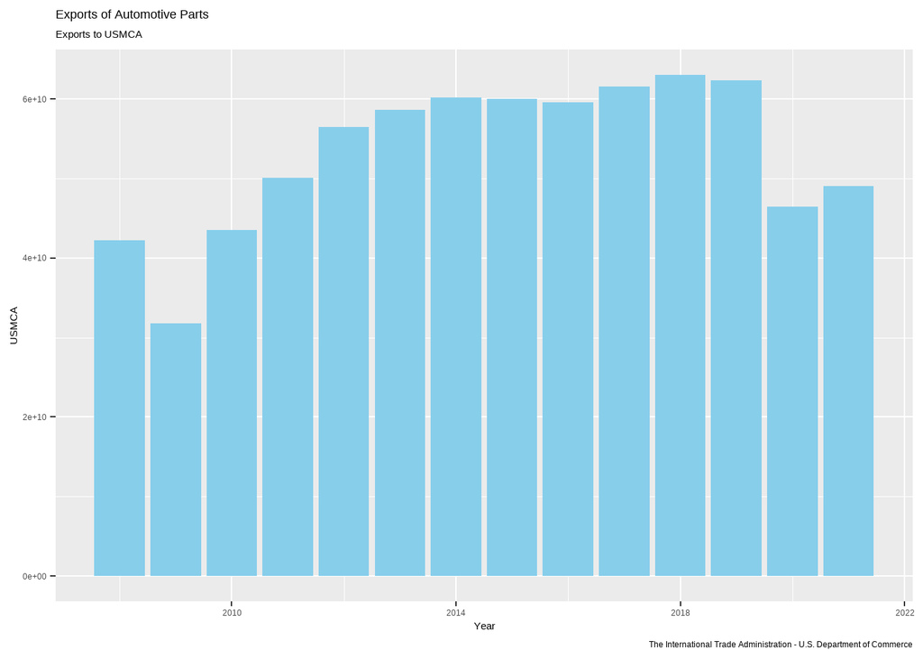

```r
# USMCA Exports by Year
ggplot(exports, aes(x=Year, y=USMCA)) +
  geom_bar(stat = "identity", fill="skyblue") + scale_fill_grey() + # Add bars to the plot
    labs(title = "Exports of Automotive Parts", # Add a title
       subtitle = "Exports to USMCA", # Add a subtitle
       caption = "The International Trade Administration - U.S. Department of Commerce", # Add a caption
       x = "Year")
```

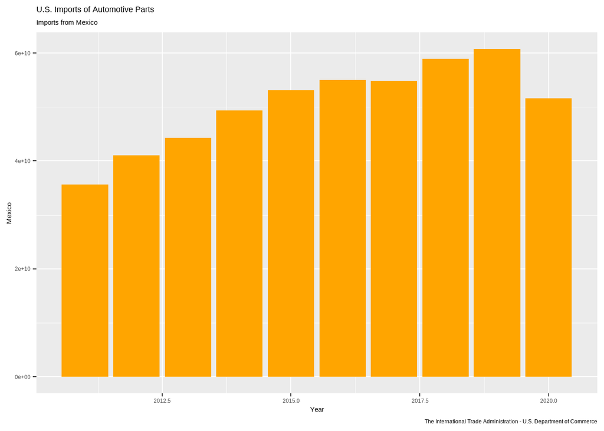

```r
# US Imports by Year
ggplot(imports, aes(x=Year, y=Mexico)) +
  geom_bar(stat="identity", fill="orange") + scale_fill_grey() + # Add bars to the plot
  labs(title = "U.S. Imports of Automotive Parts", # Add a title
       subtitle = "Imports from Mexico", # Add a subtitle
       caption = "The International Trade Administration - U.S. Department of Commerce", # Add a caption
       x = "Year")
```

## Domestic Sales & Sales Passenger Cars

### Extract data

```r
domestic_sales<-domestic_production_sales %>% select(Year, Domestic_Sales:Sales_Commercial_Vehicles) %>% filter(Year>1993)
```

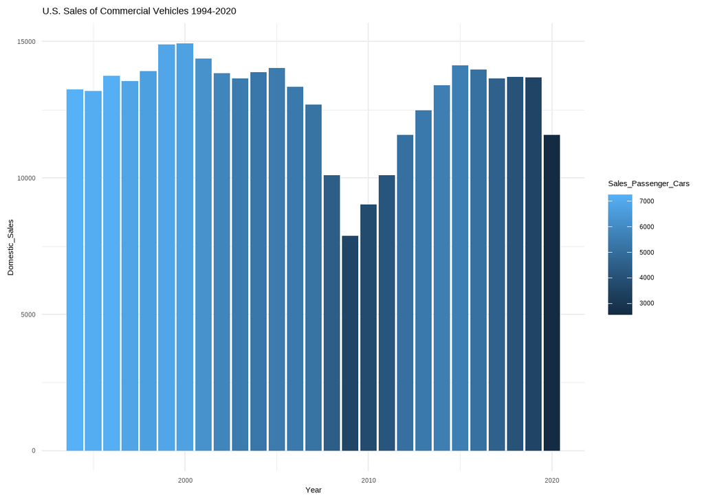

```r
ggplot(domestic_sales,aes(x=Year,y=Domestic_Sales,fill=Sales_Passenger_Cars))+
  geom_bar(stat="identity")+
  theme_minimal()+
  labs(title="U.S. Sales of Commercial Vehicles 1994-2020")
```

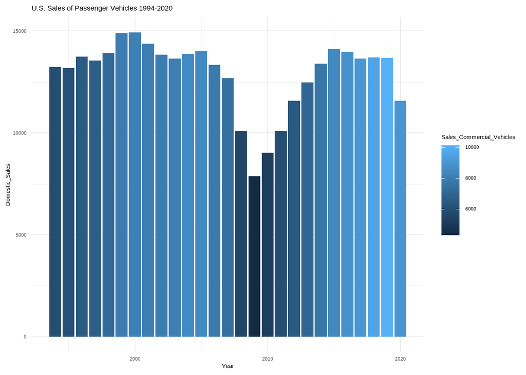

```r
ggplot(domestic_sales,aes(x=Year,y=Domestic_Sales,fill=Sales_Commercial_Vehicles))+
  geom_bar(stat="identity")+
  theme_minimal()+
  labs(title="U.S. Sales of Passenger Vehicles 1994-2020")
```

## Boxplots

- **Boxplots** display how your data’s values are spread out. Boxplots are standardized way of displaying the distribution of data based on a five number summary:
1. minimum
2. first quartile [Q1]
3. median
4. third quartile [Q3]
5. maximum

### create a new dataset to display boxplots of exports by region

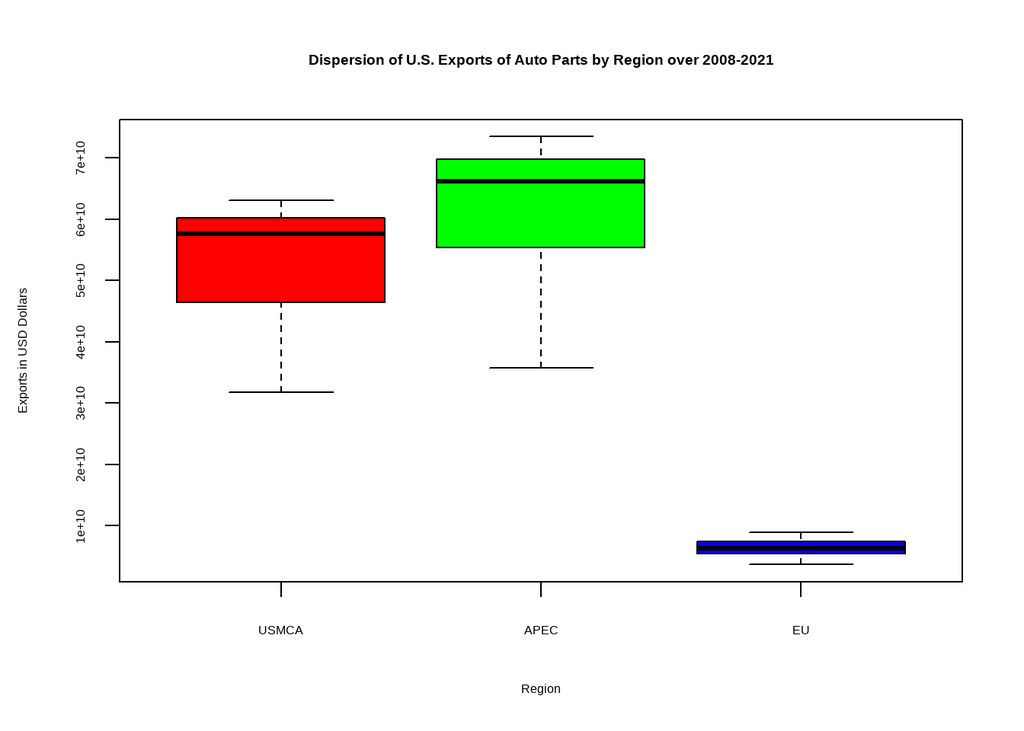

```r
exports_boxplots=subset(exports,select=-c(Year,World))
boxplot(exports_boxplots,data=data,main="Dispersion of U.S. Exports of Auto Parts by Region over 2008-2021",
        xlab="Region",ylab="Exports in USD Dollars",col=rainbow(ncol(trees)))
```

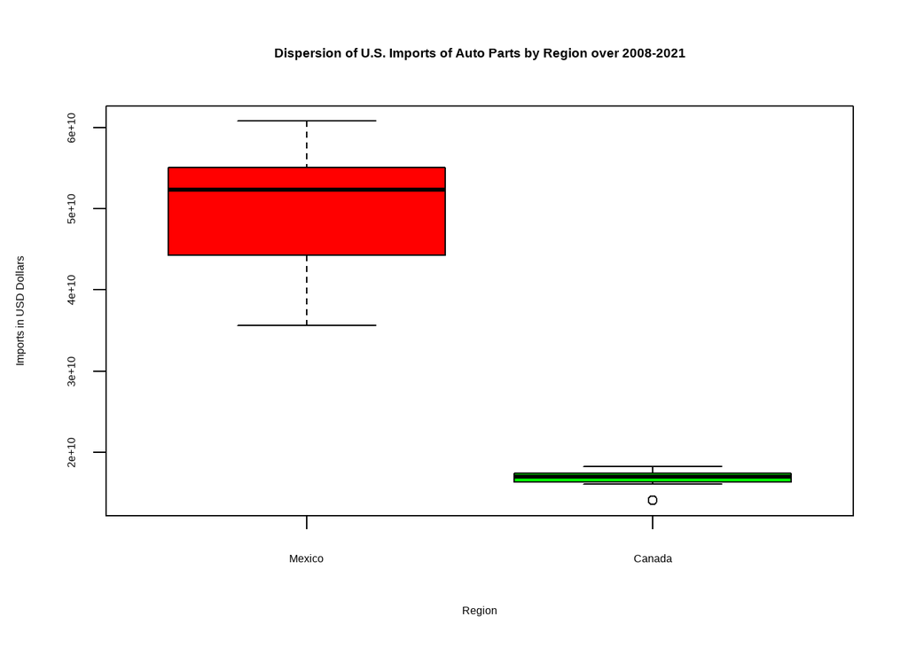

```r
# create a new dataset to display boxplots of imports by country
imports_boxplots=subset(imports,select=-c(Year,World))
boxplot(imports_boxplots,data=data,main="Dispersion of U.S. Imports of Auto Parts by Region over 2008-2021",
        xlab="Region",ylab="Imports in USD Dollars",col=rainbow(ncol(trees)))
```

### Domestic Sales by Year (Time Series Data)

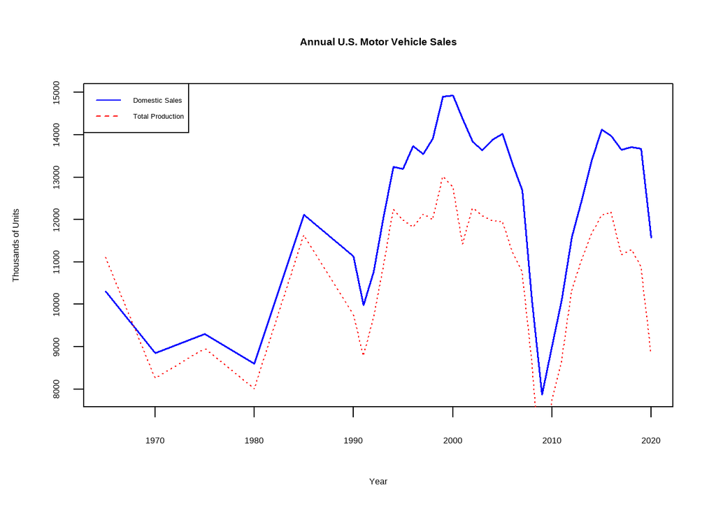

```r
plot(domestic_production_sales$Year,domestic_production_sales$Domestic_Sales, type="l",col="blue", lwd=1.5, xlab ="Year",ylab ="Thousands of Units", main = "Annual U.S. Motor Vehicle Sales")
lines(domestic_production_sales$Year,domestic_production_sales$Total_Production,col="red",lty=3)
legend("topleft", legend=c("Domestic Sales", "Total Production"),
       col=c("blue", "red"), lty = 1:2, cex=0.8)
```

### introducing time series libraries

```r
library(tseries)
```

```r
library(dygraphs)
```

```r
domestic_production_ts<-ts(domestic_production_sales$Domestic_Sales,domestic_production_sales$Year,start=1965,end=2020,frequency=1)
dygraph(domestic_production_ts, main="Annual U.S. Motor Vehicle Sales", ylab="Thousands of Units") %>%
  dyOptions(colors = RColorBrewer::brewer.pal(4, "Dark2")) %>%
  dyShading(from = "2000-12-1",to = "2020-12-1", color="#FFE6E6") %>%
  dyShading(from="1965-1-1", to="2006-05-31", color="#CCEBD6") %>%
  dyEvent("2007-1-1","U.S. Subprime Mortage Crisis",labelLoc="bottom")
```

[interactive chart not shown]

## Linear Regression Analysis - PREDICTION

### A * **linear regression analysis** consists in estimating a linear relationship between one dependent variable and one or more explanatory independent variables. For example, what are the factors that affect the weekly sales for a company?

### Data manipulation

```r
us_auto_sales<-domestic_production_sales %>% select(Year,Domestic_Sales:Sales_Commercial_Vehicles) %>% filter(Year>2006)
us_auto_sales<-right_join(us_auto_sales, us_consumer_confidence, by='Year') # join 2 databases by using year as a reference.
us_auto_sales<-us_auto_sales[!(us_auto_sales$Year=="2021"),] # remove year 2021
```

### correlation plot

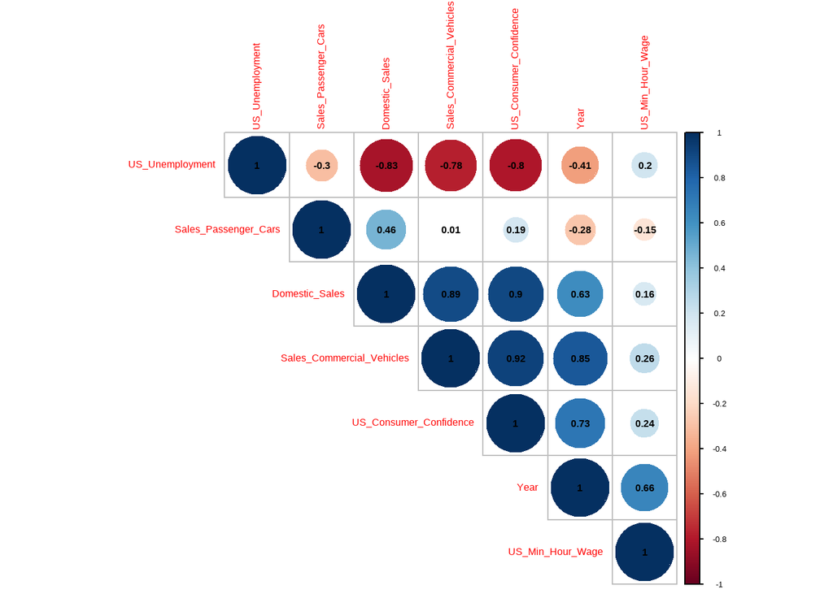

```r
corrplot(cor(us_auto_sales),type='upper',order='hclust',addCoef.col='black')
```

### scatter plot

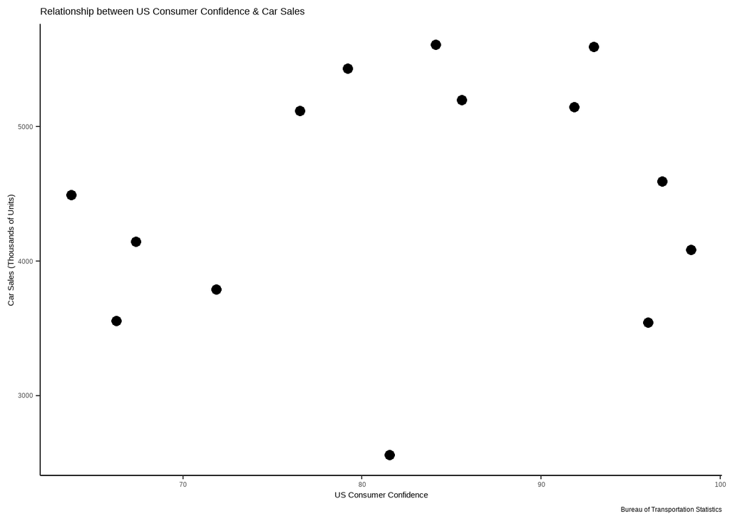

```r
ggplot(us_auto_sales, aes(x=US_Consumer_Confidence, y=Sales_Passenger_Cars)) +
  geom_point(shape=19, size=3) + # Add points of the scatterplot
  labs(title = "Relationship between US Consumer Confidence & Car Sales", # Add title
       caption = "Bureau of Transportation Statistics", # Add data source
       x="US Consumer Confidence", y="Car Sales (Thousands of Units)") +  # Rename axes titles
  theme_classic() # Use a predefined theme of the graph
```

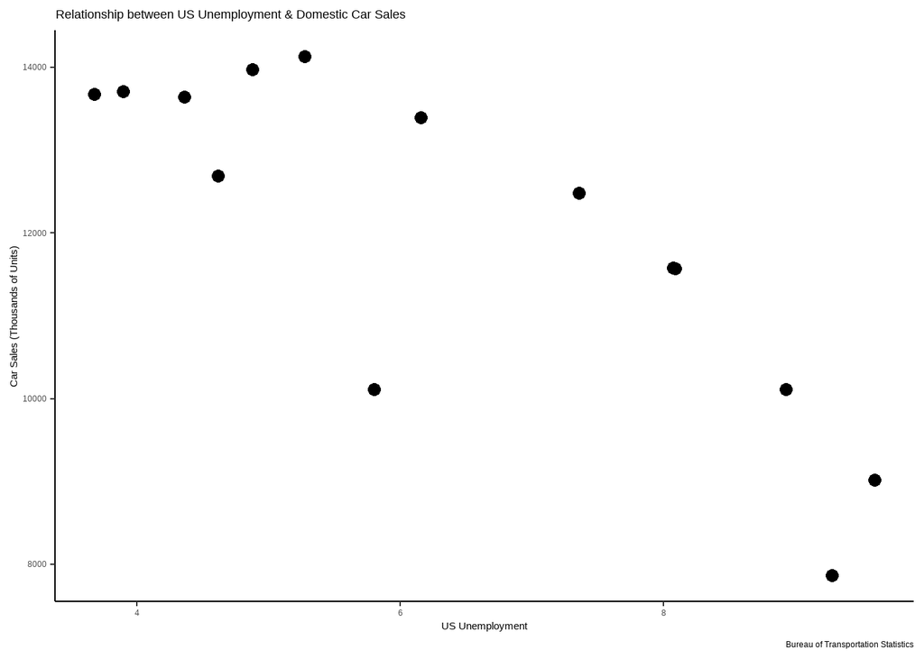

```r
ggplot(us_auto_sales, aes(x=US_Unemployment, y=Domestic_Sales)) +
  geom_point(shape=19, size=3) + # Add points of the scatterplot
  labs(title = "Relationship between US Unemployment & Domestic Car Sales", # Add title
       caption = "Bureau of Transportation Statistics", # Add data source
       x="US Unemployment", y="Car Sales (Thousands of Units)") +  # Rename axes titles
  theme_classic() # Use a predefined theme of the graph
```

### estimation of linear regression model

```r
model1<-lm(Domestic_Sales~US_Consumer_Confidence+US_Unemployment+US_Min_Hour_Wage,data=us_auto_sales)
summary(model1)
```

```
##
## Call:
## lm(formula = Domestic_Sales ~ US_Consumer_Confidence + US_Unemployment +
##     US_Min_Hour_Wage, data = us_auto_sales)
##
## Residuals:
##     Min      1Q  Median      3Q     Max
## -1461.8  -730.4   268.1   541.9  1039.0
##
## Coefficients:
##                        Estimate Std. Error t value Pr(>|t|)
## (Intercept)             3884.22    4053.77   0.958   0.3606
## US_Consumer_Confidence    92.50      47.64   1.941   0.0809 .
## US_Unemployment         -395.50     269.87  -1.466   0.1735
## US_Min_Hour_Wage         433.07     657.40   0.659   0.5249
## ---
## Signif. codes:  0 '***' 0.001 '**' 0.01 '*' 0.05 '.' 0.1 ' ' 1
##
## Residual standard error: 891.7 on 10 degrees of freedom
## Multiple R-squared:  0.8498, Adjusted R-squared:  0.8048
## F-statistic: 18.86 on 3 and 10 DF,  p-value: 0.0001934
```

```r
model2<-lm(Sales_Commercial_Vehicles~US_Consumer_Confidence+US_Unemployment+US_Min_Hour_Wage,data=us_auto_sales)
summary(model2)
```

```
##
## Call:
## lm(formula = Sales_Commercial_Vehicles ~ US_Consumer_Confidence +
##     US_Unemployment + US_Min_Hour_Wage, data = us_auto_sales)
##
## Residuals:
##    Min     1Q Median     3Q    Max
## -862.5 -367.7 -101.7  193.0 1851.3
##
## Coefficients:
##                        Estimate Std. Error t value Pr(>|t|)
## (Intercept)            -2876.01    3390.60  -0.848   0.4162
## US_Consumer_Confidence   100.17      39.85   2.514   0.0307 *
## US_Unemployment         -232.00     225.72  -1.028   0.3283
## US_Min_Hour_Wage         516.57     549.85   0.939   0.3696
## ---
## Signif. codes:  0 '***' 0.001 '**' 0.01 '*' 0.05 '.' 0.1 ' ' 1
##
## Residual standard error: 745.8 on 10 degrees of freedom
## Multiple R-squared:  0.8662, Adjusted R-squared:  0.826
## F-statistic: 21.57 on 3 and 10 DF,  p-value: 0.0001096
```

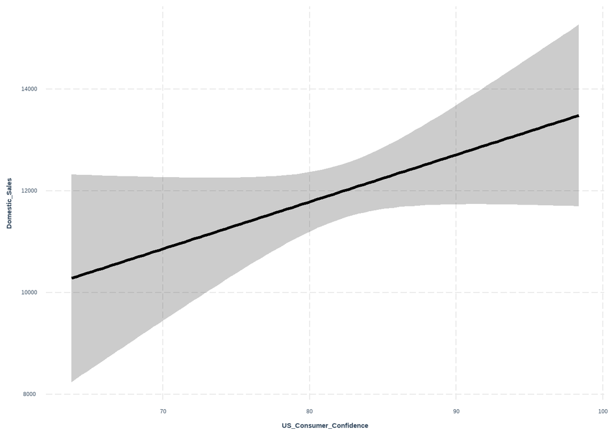

```r
effect_plot(model1,pred=US_Consumer_Confidence,interval=TRUE)
```

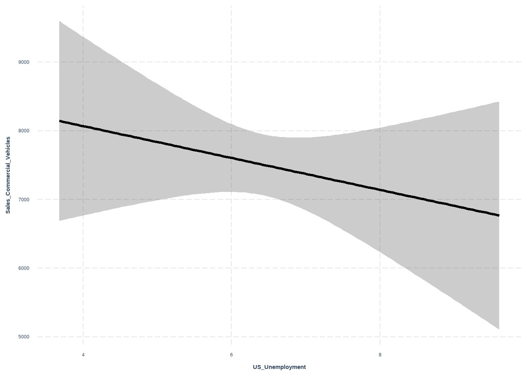

```r
effect_plot(model2,pred=US_Unemployment,interval=TRUE)
```

## Time Series Data - FORECASTING

- **Time series analysis** is a specific way of analyzing a sequence of data points collected over a period of time. Generally, time series analysis requires a large number of data points to ensure consistency and reliability (Tableau Software).

### loading time series libraries

```r
library(tseries)   # time series analysis and computational finance
library(forecast)  # provides methods and tools for displaying and analyzing univariate time series forecast
library(astsa)     # applied statistical time series analysis
```

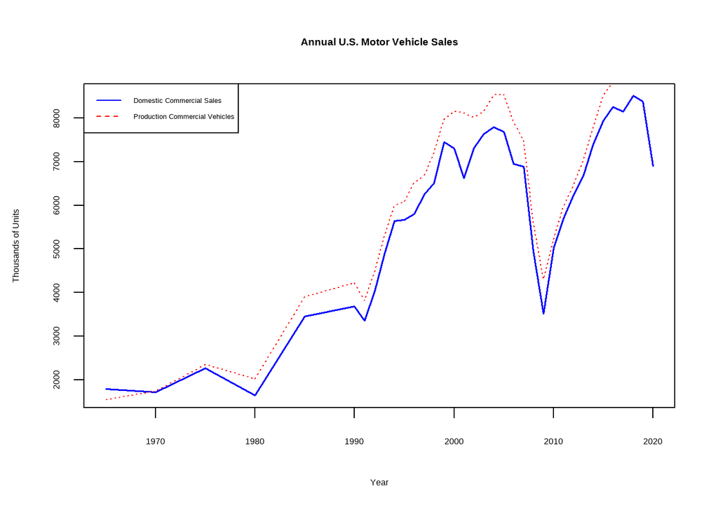

```r
plot(domestic_production_sales$Year,domestic_production_sales$Production_Commercial_Vehicles, type="l",col="blue", lwd=1.5, xlab ="Year",ylab ="Thousands of Units", main = "Annual U.S. Motor Vehicle Sales")
lines(domestic_production_sales$Year,domestic_production_sales$Sales_Commercial_Vehicles,col="red",lty=3)
legend("topleft", legend=c("Domestic Commercial Sales", "Production Commercial Vehicles"),
       col=c("blue", "red"), lty = 1:2, cex=0.8)
```

### Forecasting using Autoregressive Model - Forecast the variable of interest using a linear combination of its past values.

```r
summary(autoregressive_model<-arma(domestic_production_sales$Total_Production,order=c(1,0)))
```

```
##
## Call:
## arma(x = domestic_production_sales$Total_Production, order = c(1,     0))
##
## Model:
## ARMA(1,0)
##
## Residuals:
##     Min      1Q  Median      3Q     Max
## -3531.7  -393.0   339.7   682.4  2855.8
##
## Coefficient(s):
##            Estimate  Std. Error  t value Pr(>|t|)
## ar1          0.6945      0.1238    5.608 2.05e-08 ***
## intercept 3218.7442   1347.5370    2.389   0.0169 *
## ---
## Signif. codes:  0 '***' 0.001 '**' 0.01 '*' 0.05 '.' 0.1 ' ' 1
##
## Fit:
## sigma^2 estimated as 1589433,  Conditional Sum-of-Squares = 54040716,  AIC = 620.2
```

```r
autoregressive_model_forecast<-forecast(autoregressive_model$fitted,h=5,level=c(95))
autoregressive_model_forecast
```

```
##    Point Forecast    Lo 95    Hi 95
## 37        10808.3 8993.558 12623.05
## 38        10808.3 8350.151 13266.46
## 39        10808.3 7843.218 13773.39
## 40        10808.3 7411.107 14205.50
## 41        10808.3 7028.071 14588.54
```

### Forecasting using Moving Average Model - The forecasted value is a linear combination of the mean of the series and past error terms.

```r
summary(ma_model<-arma(domestic_production_sales$Total_Production,order=c(0,1)))
```

```
##
## Call:
## arma(x = domestic_production_sales$Total_Production, order = c(0,     1))
##
## Model:
## ARMA(0,1)
##
## Residuals:
##     Min      1Q  Median      3Q     Max
## -3777.9  -563.2   600.5   988.2  2410.8
##
## Coefficient(s):
##            Estimate  Std. Error  t value Pr(>|t|)
## ma1       5.625e-01   1.103e-01     5.10 3.39e-07 ***
## intercept 1.057e+04   3.525e+02    29.98  < 2e-16 ***
## ---
## Signif. codes:  0 '***' 0.001 '**' 0.01 '*' 0.05 '.' 0.1 ' ' 1
##
## Fit:
## sigma^2 estimated as 1905647,  Conditional Sum-of-Squares = 64904462,  AIC = 626.74
```

```r
ma_model_forecast<-forecast(ma_model$fitted,h=5,level=c(95))
ma_model_forecast
```

```
##    Point Forecast    Lo 95    Hi 95
## 37       10745.38 9248.956 12241.80
## 38       10745.38 9158.350 12332.41
## 39       10745.38 9072.645 12418.11
## 40       10745.38 8991.122 12499.63
## 41       10745.38 8913.223 12577.53
```

### Forecasting using ARMA - Combines autoregressive and moving average

```r
summary(arma_model<-arma(domestic_production_sales$Total_Production,order=c(1,1)))
```

```
##
## Call:
## arma(x = domestic_production_sales$Total_Production, order = c(1,     1))
##
## Model:
## ARMA(1,1)
##
## Residuals:
##     Min      1Q  Median      3Q     Max
## -3416.8  -343.5   371.8   696.8  2885.0
##
## Coefficient(s):
##            Estimate  Std. Error  t value Pr(>|t|)
## ar1          0.6376      0.1727    3.693 0.000222 ***
## ma1          0.1102      0.1951    0.565 0.572042
## intercept 3815.2122   1852.1163    2.060 0.039406 *
## ---
## Signif. codes:  0 '***' 0.001 '**' 0.01 '*' 0.05 '.' 0.1 ' ' 1
##
## Fit:
## sigma^2 estimated as 1575535,  Conditional Sum-of-Squares = 53570711,  AIC = 621.89
```

```r
arma_model_forecast<-forecast(arma_model$fitted,h=5,level=c(95))
arma_model_forecast
```

```
##    Point Forecast    Lo 95    Hi 95
## 37       10812.01 8864.918 12759.10
## 38       10812.01 8342.444 13281.58
## 39       10812.01 7912.639 13711.38
## 40       10812.01 7538.794 14085.23
## 41       10812.01 7203.474 14420.55
```

# References

Tableau Software. Time Series Analysis: Definition, Types, Techniques, and When its Used (Source:https://www.tableau.com/learn/articles/time-series-analysis)